# SCGSR final report

2023-05-03

## Sample Summary

**click to open**

Soils from northwest Alaska were homogenized and pre-incubated at -2 and -6 degrees Celsius for three months after which they were incubated at 2,4,6,8,10 degrees Celsius for one week. After the week long incubation soils were extracted using 0.5M K2SO4, and chloroform extracted to measure microbial biomass and nutrient concentrations. Sub-samples were also sent to PNNL for MPLEx (Methanol chloroform extraction) to provide more comprehensive analysis of the molecular composition of organic matter using FT-ICR, NMR, GC-MS and LC-MS techniques. Lipidomics were also performed to ascertain if there were any significant shifts in microbial biomass.

## Respiration Results

**click to open**

Respiration measurements were taken daily during the incubation using a Li-850 bench top respiration unit. Below are the respiration rates for each sample, as well as the calculates total C respired. Respiration varied significantly by incubation day, incubation temperature (LME, p < 0.001), and pre-incubation temperature (LME, p = 0. 0137). Asterisks signify significant variation in ANOVA analysis (p<0.05).

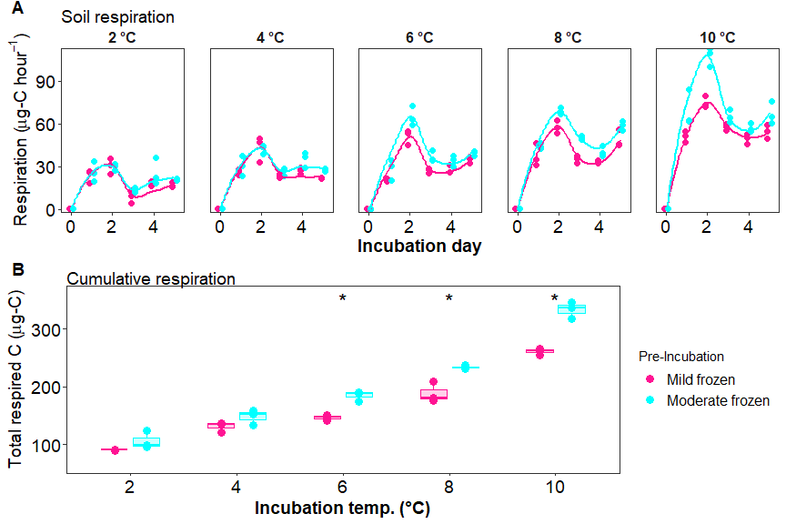

## Soil Nutrients

**click to open**

Soil K2SO4 extracts were utilized to measure ammonium, Nitrate, Total free primary amines, phosphate, Total reducing sugars. Below are the concentration data. An asterisks indicates a significant (p<= 0.05, ANOVA) difference in pre-incubation temperature. Overall ANOVA showed that TRS changed significantly due to pre-incubation, incubation temperature, and the interaction (ANOVA, p < 0.001). Pre-incubated moderate freeze soil TRS concentrations remained similar to non-incubated soils which had significantly higher concentrations than pre-incubated mild freeze soils (ANOVA, f = 18.18, p < 0.013). Though there was a trend for pre-incubated and incubated soils to have increased concentrations of all N forms (Ammonium, Nitrate, and TFPA) when compared to non-incubated soils, the pre-incubation temperatures showed no significant differences after the incubation (ANOVA, p> 0.0696405). Pre-incubation and incubation temperatures had little to no effect on phosphate concentrations in incubated soils (ANOVA, p > 0.49)

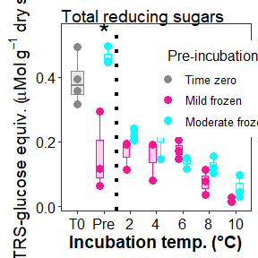

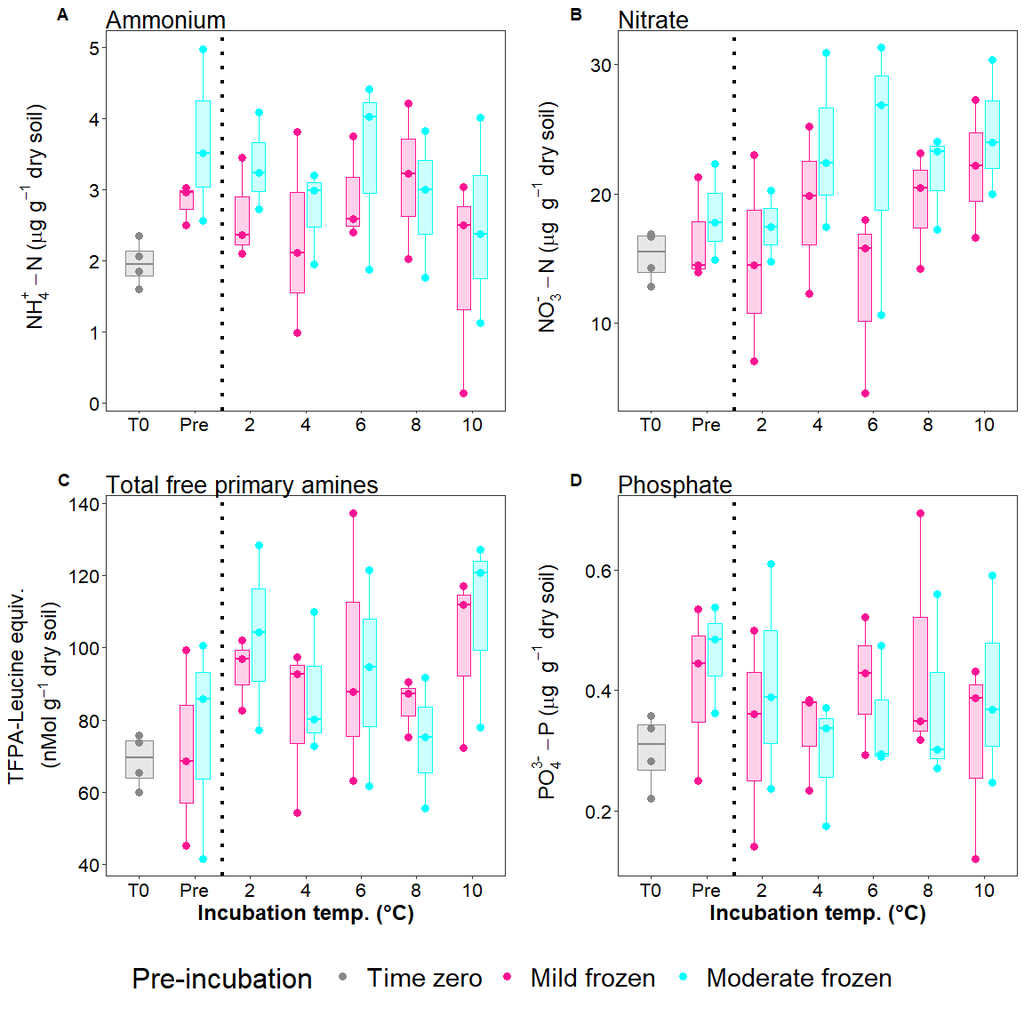

## Microbial Biomass

**click to open**

Microbial biomass C and N was measures to identify changes in biomass through the incubation. An asterisks indicates a significant (p<= 0.05) difference in pre-incubation temperature.Overall, MBC following the incubation was significantly greater in soils that experienced the moderate freeze compared to mild freeze (ANOVA, f = 5.19, p = 0.0138), whereas incubation temperature and interaction did not affect MBC significantly (ANOVA, p > 0.071). For soils that experienced moderate freeze, post-incubation MBC remained more or less unchanged compared to T0 (Dunnett, p > 0.25). On the other hand, soils that experienced mild freeze had numerically lower MBC compared to T0; however, these values were highly variable and therefore not significant overall (Dunnett, p > 0.25).

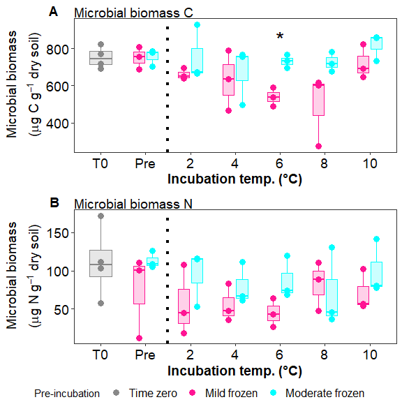

## GC-MS

**click to open**

Below is the relative quantification of compounds identified by gas chromatography within the MPLEx extracts.Little to no variation was identified that corresponds to the more broad metrics above in the soil nutrient section.The statistics suggested that incubation temperature induced significant variation for all compounds and saccharides only (p<0.022, PERMANOVA), though separation was not identifiable on the PCAs. The majority of compounds measured were unidentified.

#### PCA

[figure not shown]

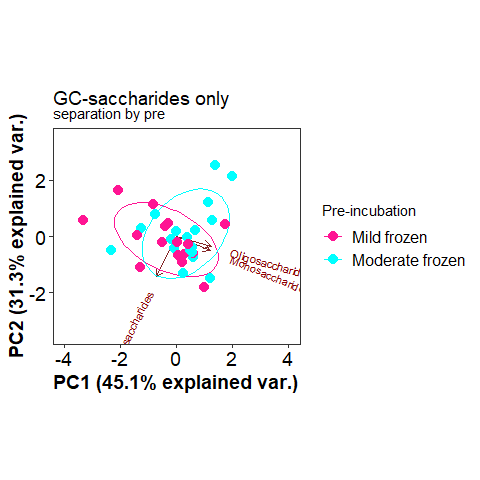

## LC-MS

**click to open**

Below is the relative quantification of compounds identified by liquid chromatography within the MPLEx extracts.Little to no variation was identified that corresponds to the more broad metrics above in the soil nutrient section.The statistics suggested that incubation temperature induced significant variation for all compounds and saccharides only (p<0.005, PERMANOVA), though separation was not identifiable on the PCAs. The majority of compounds measured were unidentified.

#### PCA

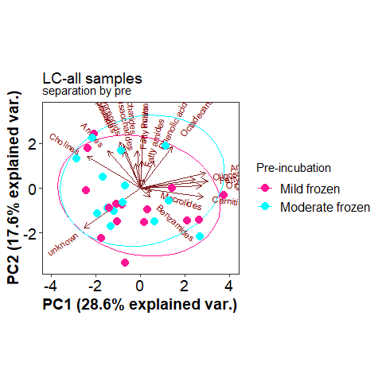

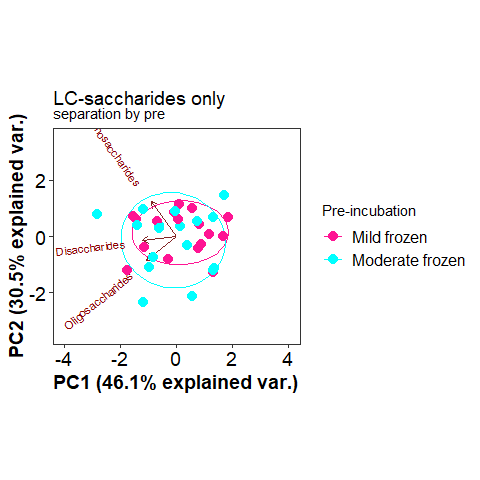

[figure not shown]

## Lipids

**click to open**

Lipid analysis was done via liquid chrometography on MEPLEx extracts. Some variation was identified between pre-incubation temperatures, though little was biologically significant. Conclusion that small changes in biomass were present but not significant. Incubation temperature induced significant variation for lipids in the negative mode only (p=0.009, PERMANOVA), though separation was not identifiable on the PCAs. A big missing piece to this analysis would be community composition.

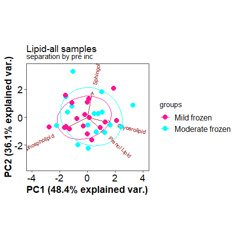

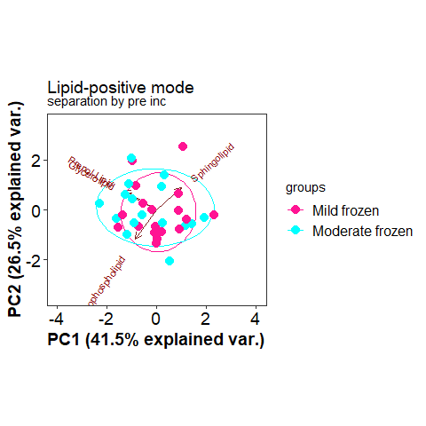

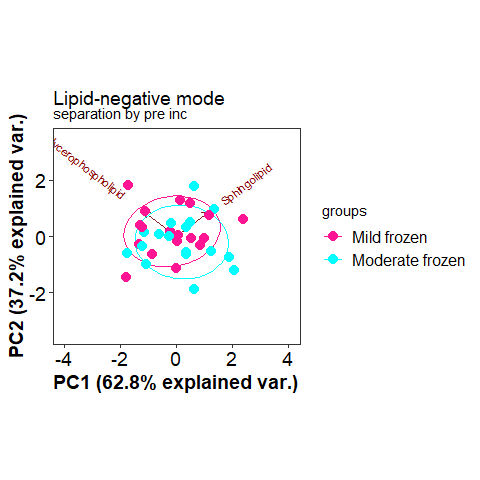

## FT-MS (FT-ICR)

**click to open**

FTICR was performed on MEPLEx extracts to gain a qualitative understanding of the changes in organic matter composition after the incubation. We identified differences in the total number of unique compounds between mild and moderate freeze soils, before and after the incubation. Unique compounds between mild and moderate freeze soils are visualized on van krevelen diagrams corresponding to H/C (hydrogen to carbon) vs. O/C (oxygen to carbon) content. This could be indicative of microbial processing of organic matter and production of new organic compounds. The PCA with both layers showed no separation based on pre incubation and incubation temperature. When looking at non-polar layer PCA we see a separation between the mild and moderate freeze driven by the aromatics, and condensed aromatics in the mild freeze samples. The pre incubation explains ~17% of the variation while the incubation explains ~18% of the variation (PERMANOVA, F > 5.54, p = 0.001).

#### FTICR Van krevelen diagrams:

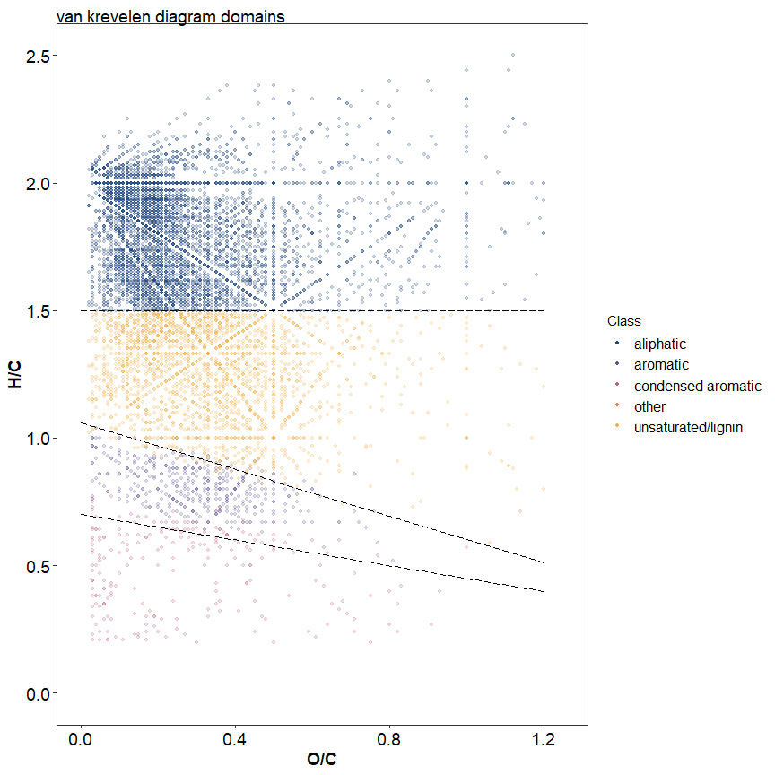

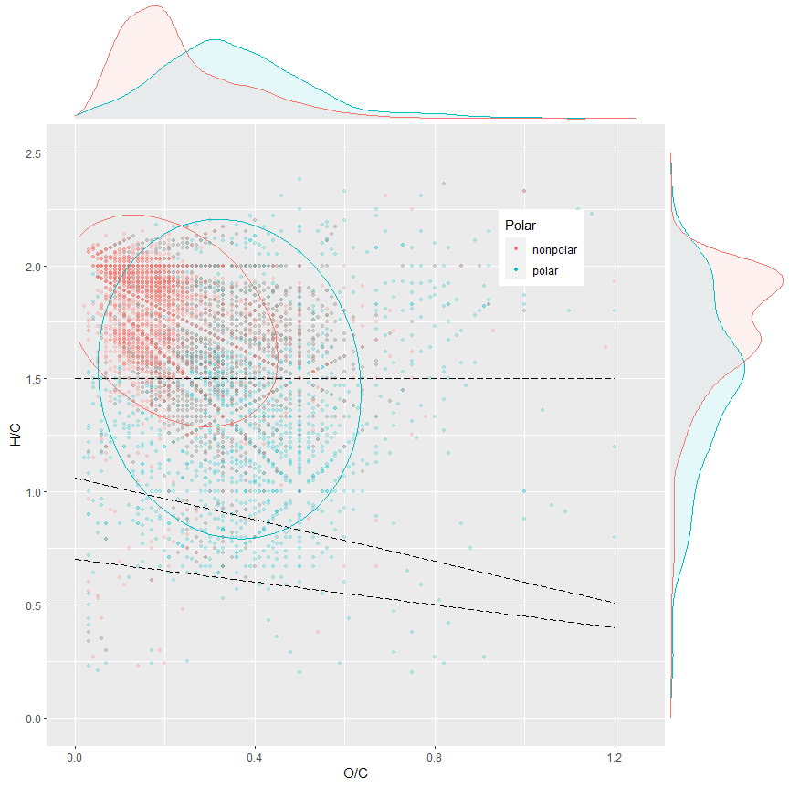

#### Unique peaks at each incubation temperature

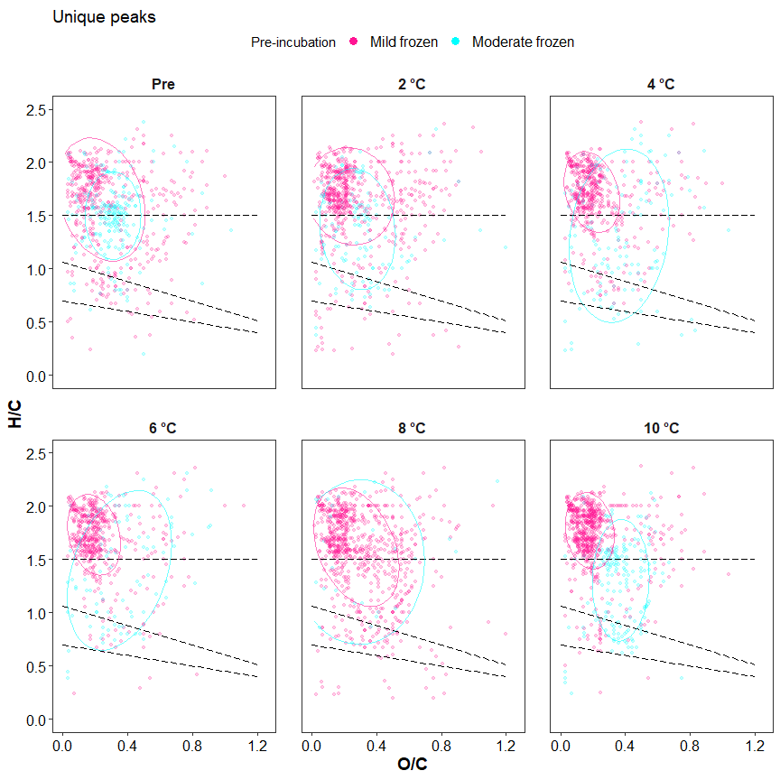

| Class | -2_Pre | -6_Pre | -2_2 | -6_2 | -2_4 | -6_4 | -2_6 | -6_6 | -2_8 | -6_8 | -2_10 | -6_10 |
| --- | --- | --- | --- | --- | --- | --- | --- | --- | --- | --- | --- | --- |
| aliphatic | 313 | 114 | 465 | 49 | 402 | 56 | 408 | 46 | 520 | 14 | 566 | 60 |
| aromatic | 34 | 13 | 18 | 16 | 21 | 14 | 13 | 18 | 48 | 3 | 21 | 35 |
| condensed aromatic | 15 | 2 | 27 | 3 | NA | 18 | 9 | 3 | 25 | NA | 7 | 9 |
| unsaturated/lignin | 85 | 79 | 86 | 54 | 69 | 42 | 57 | 27 | 166 | 9 | 69 | 75 |

Unique between preincubation temperatures at each incubation temperature

#### Relative Abundance of each molecular class

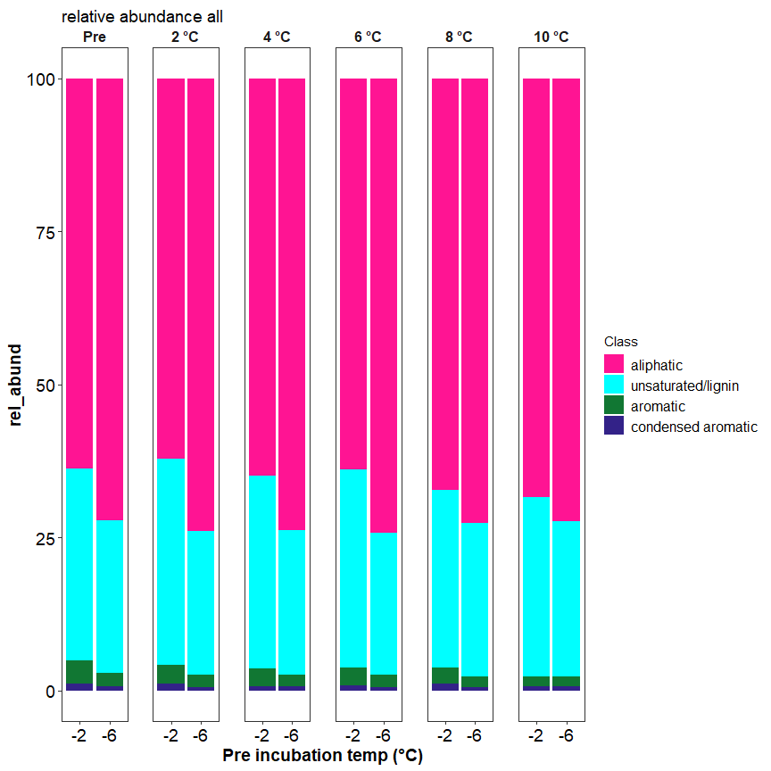

#### PCA results:

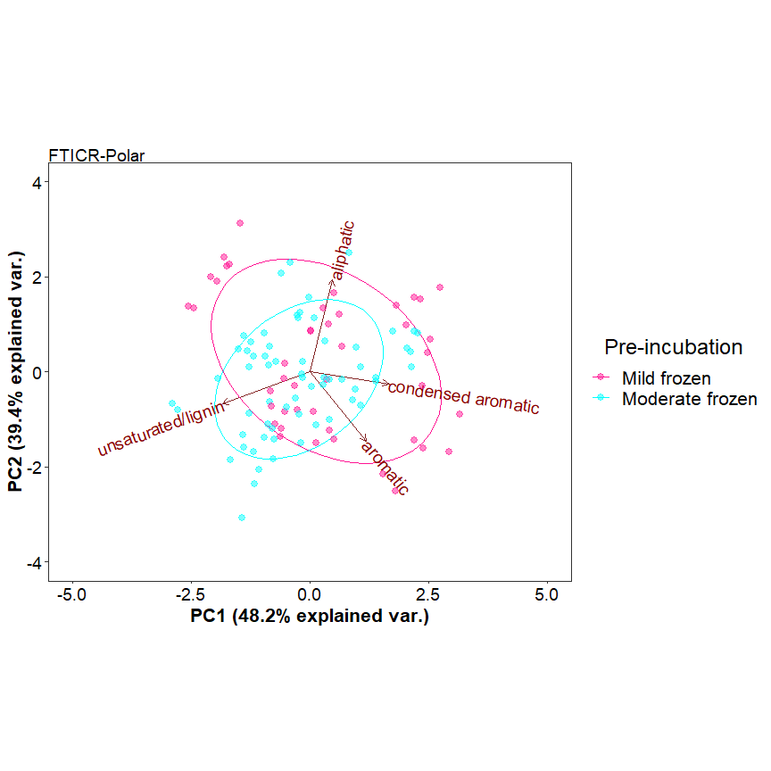

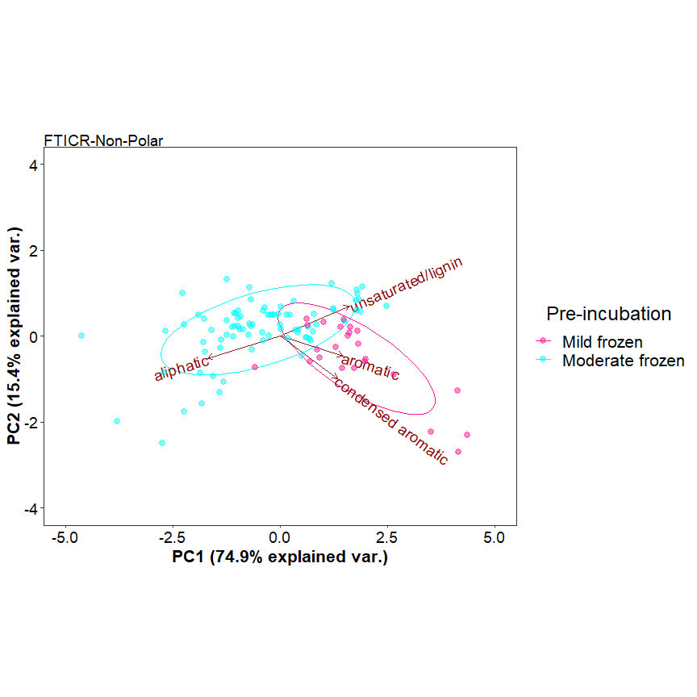

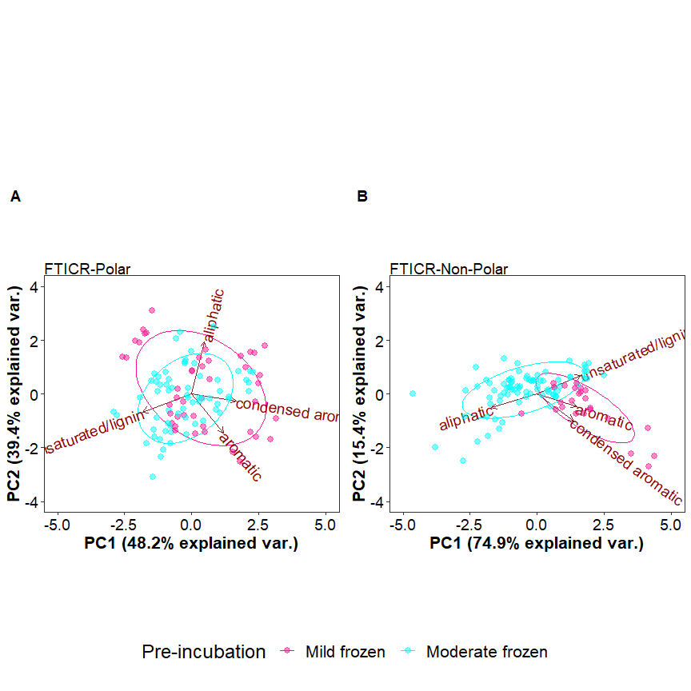

## Session Info

**Session Info**

Date run: 2024-05-31